# InjuryPrediction Analysis

Mitch

2024-08-17

## 0.1 Setting up my environment

Notes: Setting up my R environment by installing the following analysis packages

```r
install.packages("tidyverse")
install.packages("dplyr")
install.packages("skimr")
install.packages("janitor")
install.packages("magrittr")
```

## 0.2 Loading the required packages

Here, I loaded the previously installed packages

```r
library(tidyverse)
library(dplyr)
library(skimr)
library(janitor)
library(magrittr)
```

## 0.3 Upload and read csv for analysis

Here, I uploaded the injury_prediction csv and viewed the data frame

```r
injurypred <- read_csv("injury_data.csv")
head(injurypred)
```

```
## # A tibble: 6 × 7
##   Player_Age Player_Weight Player_Height Previous_Injuries Training_Intensity
##        <dbl>         <dbl>         <dbl>             <dbl>              <dbl>
## 1         24          66.3          176.                 1              0.458
## 2         37          71.0          175.                 0              0.227
## 3         32          80.1          186.                 0              0.614
## 4         28          87.5          176.                 1              0.253
## 5         25          84.7          190.                 0              0.578
## 6         38          75.8          207.                 1              0.359
## # ℹ 2 more variables: Recovery_Time <dbl>, Likelihood_of_Injury <dbl>
```

```r
str(injurypred)
```

```
## spc_tbl_ [1,000 × 7] (S3: spec_tbl_df/tbl_df/tbl/data.frame)
##  $ Player_Age          : num [1:1000] 24 37 32 28 25 38 24 36 28 28 ...
##  $ Player_Weight       : num [1:1000] 66.3 71 80.1 87.5 84.7 ...
##  $ Player_Height       : num [1:1000] 176 175 186 176 190 ...
##  $ Previous_Injuries   : num [1:1000] 1 0 0 1 0 1 0 1 1 1 ...
##  $ Training_Intensity  : num [1:1000] 0.458 0.227 0.614 0.253 0.578 ...
##  $ Recovery_Time       : num [1:1000] 5 6 2 4 1 4 2 3 1 1 ...
##  $ Likelihood_of_Injury: num [1:1000] 0 1 1 1 1 0 0 1 1 0 ...
##  - attr(*, "spec")=
##   .. cols(
##   ..   Player_Age = col_double(),
##   ..   Player_Weight = col_double(),
##   ..   Player_Height = col_double(),
##   ..   Previous_Injuries = col_double(),
##   ..   Training_Intensity = col_double(),
##   ..   Recovery_Time = col_double(),
##   ..   Likelihood_of_Injury = col_double()
##   .. )
##  - attr(*, "problems")=<externalptr>
```

## 0.4 Fix any variables in data frame to match the csv

Here, I altered the data types to match the original csv

```r
injurypred <- injurypred %>%
  mutate(
    Player_Age = as.integer(Player_Age),
    Player_Weight = as.numeric(Player_Weight),
    Player_Height = as.numeric(Player_Height),
    Previous_Injuries = as.integer(Previous_Injuries),
    Training_Intensity = as.numeric(Training_Intensity),
    Recovery_Time = as.integer(Recovery_Time),
    Likelihood_of_Injury = as.integer(Likelihood_of_Injury)
  )
```

## 0.5 Find the average player age, weight, and height

Here, I found the average player age, weight and height to build foundation

```r
injurypred %>%
  summarise(average_age = mean(Player_Age, na.rm = TRUE))
```

```
## # A tibble: 1 × 1
##   average_age
##         <dbl>
## 1        28.2
```

```r
injurypred %>%
  summarise(average_weight = mean(Player_Weight, na.rm = TRUE))
```

```
## # A tibble: 1 × 1
##   average_weight
##            <dbl>
## 1           74.8
```

```r
injurypred %>%
  summarise(average_height = mean(Player_Height, na.rm = TRUE))
```

```
## # A tibble: 1 × 1
##   average_height
##            <dbl>
## 1           180.
```

## 0.6 Count total number of players with and without previous injuries

Here, I counted all players that do and do not have previous injuries 0=no, 1=yes

```r
table(injurypred$Previous_Injuries)
```

```
##
##   0   1
## 485 515
```

## 0.7 Calculate total number of players older and younger that average age

Here, I added how many players were older and youger than the average age

```r
sum(injurypred$Player_Age > 28.2)
```

```
## [1] 494
```

```r
sum(injurypred$Player_Age < 28.2)
```

```
## [1] 506
```

## 0.8 Calculate the min and max player age, weight, and height

Here, I calculated the min and max

```r
min(injurypred$Player_Age)
```

```
## [1] 18
```

```r
max(injurypred$Player_Age)
```

```
## [1] 39
```

```r
min(injurypred$Player_Weight)
```

```
## [1] 40.19191
```

```r
max(injurypred$Player_Weight)
```

```
## [1] 104.6501
```

```r
min(injurypred$Player_Height)
```

```
## [1] 145.2857
```

```r
max(injurypred$Player_Height)
```

```
## [1] 207.3087
```

```r
min(injurypred$Training_Intensity)
```

```
## [1] 3.071885e-05
```

```r
max(injurypred$Training_Intensity)
```

```
## [1] 0.9977494
```

## 0.9 Unit conversion

Here, I converted the Player weights from kg into lbs

```r
injurypred$Player_Weight <- injurypred$Player_Weight * 2.20462
head(injurypred)
```

```
## # A tibble: 6 × 7
##   Player_Age Player_Weight Player_Height Previous_Injuries Training_Intensity
##        <int>         <dbl>         <dbl>             <int>              <dbl>
## 1         24          146.          176.                 1              0.458
## 2         37          157.          175.                 0              0.227
## 3         32          177.          186.                 0              0.614
## 4         28          193.          176.                 1              0.253
## 5         25          187.          190.                 0              0.578
## 6         38          167.          207.                 1              0.359
## # ℹ 2 more variables: Recovery_Time <int>, Likelihood_of_Injury <int>
```

## 0.10 Correlate relationship between age/weight and likelihood of injury

```r
correlations <- injurypred %>%
  summarize(
    Age_vs_Injury = cor(Player_Age, Likelihood_of_Injury, use = "complete.obs"),
    Weight_vs_Injury = cor(Player_Weight, Likelihood_of_Injury, use = "complete.obs")
  )
print(correlations)
```

```
## # A tibble: 1 × 2
##   Age_vs_Injury Weight_vs_Injury
##           <dbl>            <dbl>
## 1      0.000153          0.00184
```

## 0.11 Tabulate the likelihood of injury with a previous injury

Here, I found the likelihood of getting re injured

```r
table(injurypred$Previous_Injuries,injurypred$Likelihood_of_Injury)
```

```
##
##       0   1
##   0 252 233
##   1 248 267
```

## 0.12 Compare likelihood of injury for different age groups

Here, I grouped the player ages and found the likelihood of injury for each group

```r
injurypred$Age_Group <- cut(injurypred$Player_Age,breaks = c(18, 25, 30, 35, 39),
                            labels = c("18-25", "26-30", "31-35", "36-39"))
aggregate(Likelihood_of_Injury ~ Age_Group, data = injurypred, FUN = mean)
```

```
##   Age_Group Likelihood_of_Injury
## 1     18-25            0.4656716
## 2     26-30            0.5911330
## 3     31-35            0.4976959
## 4     36-39            0.4648649
```

## 0.13 Correlate the relationship between Training Intensity and Likelihood of Injury

Here, I found a correlation between training intensity and likelihood of injury

```r
cor(injurypred$Training_Intensity, injurypred$Likelihood_of_Injury, use = "complete.obs")
```

```
## [1] 0.08925042
```

## 0.14 Calculate average recovery time

Here, I grouped players by likelihood of injury and calculated average recovery time

```r
average_recovery_time <- injurypred %>%
  group_by(Likelihood_of_Injury) %>%
  summarize(average_recovery_time=mean(Recovery_Time,na.rm = TRUE))
print(average_recovery_time)
```

```
## # A tibble: 2 × 2
##   Likelihood_of_Injury average_recovery_time
##                  <int>                 <dbl>
## 1                    0                  3.49
## 2                    1                  3.44
```

# 1 Visualizations

## 1.1 Player weight vs Previous Injuries

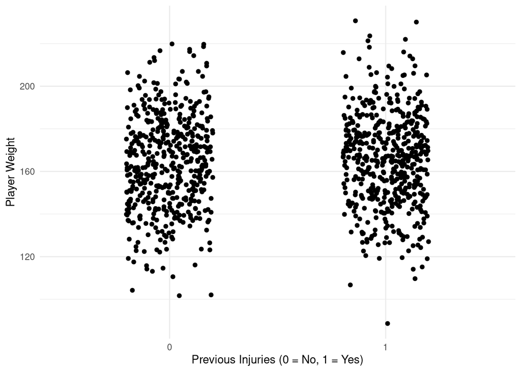

```r
ggplot(injurypred, aes(x = factor(Previous_Injuries), y = Player_Weight)) +
  geom_jitter(width = 0.2, height = 0) +
  labs(x = "Previous Injuries (0 = No, 1 = Yes)", y = "Player Weight") +
  theme_minimal()
```

## 1.2 Training intensity vs Recovery Time

Here, I plotted the relationship between intensity and recovery time

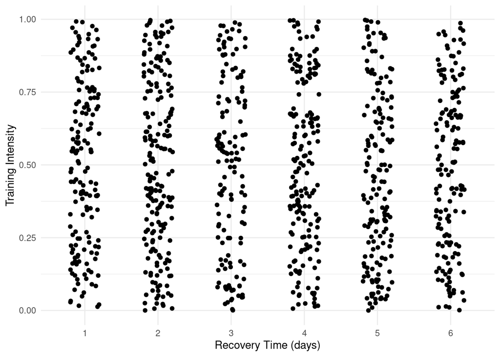

```r
ggplot(injurypred, aes(x = factor(Recovery_Time), y = Training_Intensity)) +
  geom_jitter(width = 0.2, height = 0) +
  labs(x = "Recovery Time (days)", y = "Training Intensity") +
  theme_minimal()
```